# Analysis of bitmap images under periodic boundary conditions

This tutorial explains how to analyze bitmap images under periodic boundary conditions.

A file named `periodic-binary-image.png` is saved in the same directory as this notebook. We will perform the analysis on this image.

The following cells displays the image.

```python
from IPython.display import display, Image
```

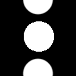

```python
display(Image("periodic-binary-image.png"))
```

When the upper and lower boundaries are connected periodically, you can see that the structure forms a white circle.

## Loading images

Use imageio to load images.

```python
import imageio
```

```python
image = imageio.v3.imread("periodic-binary-image.png", mode="L")
```

Check the image size and the histogram of pixel values.

```python
image.shape
```

```
(128, 128)
```

```python
import matplotlib.pyplot as plt
import numpy as np
```

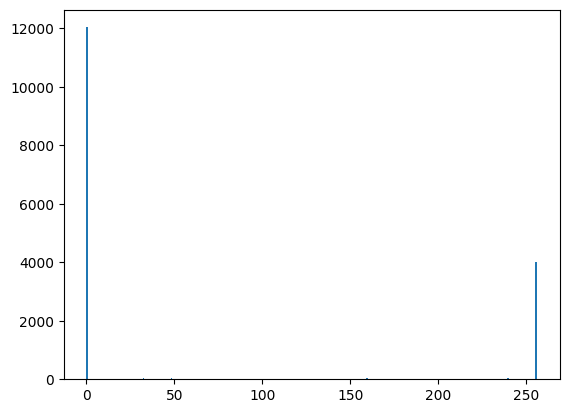

```python
plt.hist(np.ravel(image), range=(0,256), bins=256); None
```

In this tutorial, let's focus on the black areas.

Extract pixels less than 128.

```python
bitmap = image < 128
```

## When periodic boundary condition is not used

First, we compute the persistence diagrams without considering periodic boundary conditions. The process is the same as in the binary image tutorial.

```python
import homcloud.interface as hc
```

```python
hc.PDList.from_bitmap_levelset(hc.distance_transform(bitmap, signed=True), save_to="bitmap.pdgm")
```

```
PDList(path=bitmap.pdgm)
```

### Visualization of Persistence Diagrams

Displays the persistence diagram without periodic boundary condition. In this tutorial, we will analyze 1-dimensional persistence diagrams, focusing on “holes.” Here, we focus on the white holes (one-dimensional features) that appear in the black background.

By not specifying periodic boundary conditions, we can confirm how the structures that appear at the edges of the image affect the analysis.

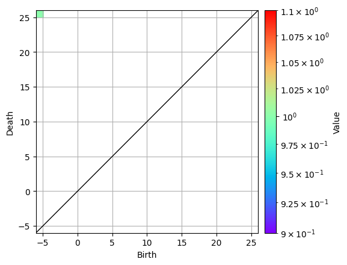

```python
pdlist = hc.PDList("bitmap.pdgm")
pd1 = pdlist.dth_diagram(1)
pd1.histogram(x_bins=28).plot(colorbar={"type":"log"})
```

There is a pair at (-6, 26).

```python
pd1.pairs()
```

```
[Pair(-6.0, 26.0)]
```

Perform inverse analysis to confirm the structure corresponding to this pair. Use a death pixel to display the positions of corresponding features.

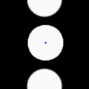

```python
death_pixel_image = hc.draw_birthdeath_pixels_2d(
    pd1.pairs(), image, draw_death=True
)
display(death_pixel_image)
```

You can see that this pair corresponds to the white hole in the center.

## When periodic boundary condition is used

Next, we calculate the persistence diagram with periodic boundary conditions.

The `periodicity` parameter is used to specify periodic boundaries. This parameter is an array with the same length as the number of dimensions of the image, and specifies whether to connect periodically for each axis with `True` (periodic) or `False` (non-periodic).

In this tutorial, the target image is two-dimensional, so we pass a two-element array to `periodicity`. In this case, we specify `[True, False]` because we want the image to be periodically connected only in the Y direction (up and down). Note that when representing images using NumPy two-dimensional arrays, the coordinate order is Y, X.

This periodicity information is necessary for both distance transformation and persistence diagram calculation. Therefore, the `periodicity` argument must be passed in both the `distance_transform` function and the `PDList.from_bitmap_levelset` function.

The `pbc` in the file name to be saved stands for Periodic Boundary Condition.

```python
periodicity=[True, False]

hc.PDList.from_bitmap_levelset(
    hc.distance_transform(bitmap, signed=True, periodicity=periodicity),
    periodicity=periodicity,
    save_to="bitmap_pbc.pdgm"
)
```

```
PDList(path=bitmap_pbc.pdgm)
```

```python
pdlist_pbc = hc.PDList("bitmap_pbc.pdgm")
pd1_pbc = pdlist_pbc.dth_diagram(1)
```

Display the 1D persistence diagram under periodic boundary condition for Y-axis.

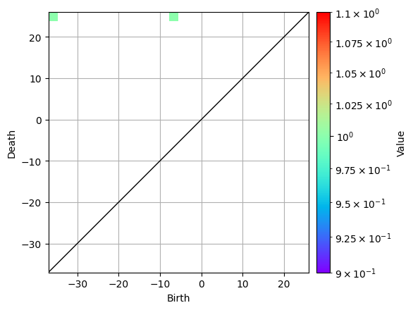

```python
pd1_pbc.histogram(x_bins=28).plot(colorbar={"type":"log"})
```

```python
pd1_pbc.pairs()
```

```
[Pair(-6.0, 25.0), Pair(-37.0, 26.0)]
```

When no periodic boundary was specified, only one pair (-6, 26) appeared in the persistence diagram. However, when periodic boundaries are specified, the number of pairs increases to two.

This means that another hole appears by periodically connecting the top and bottom of the image. In other words, by considering periodic boundaries, this image is recognized as a structure with two independent holes.

Now, let's use inverse analysis to confirm the locations of each hole in the image.

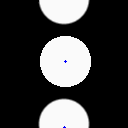

```python
death_pixel_image = hc.draw_birthdeath_pixels_2d(
    pd1_pbc.pairs(), image, draw_death=True
)
display(death_pixel_image)
```

This tutorial ends here.